# Лабораторная работа №1

Сетевые технологии

Иванов Сергей Владимирович, НПИбд-01-23

Российский университет дружбы народов, Москва, Россия

9 сентября 2025

## Цель работы

Изучение методов кодирования и модуляции сигналов с помощью высокоуровнего языка программирования Octave. Определение спектра и параметров сигнала. Демонстрация принципов модуляции сигнала на примере аналоговой амплитудной модуляции. Исследование свойства самосинхронизации сигнала.

# Выполнение работы

## Программа plot_sin.m

Запустим Octave с оконным интерфейсом. Перейдем в окно редактора. Создадим новый сценарий. Сохраним его в рабочий каталог с именем. В окне редактора повторим листинг по построению графика функции (рис. 1).

## Программа plot_sin.m

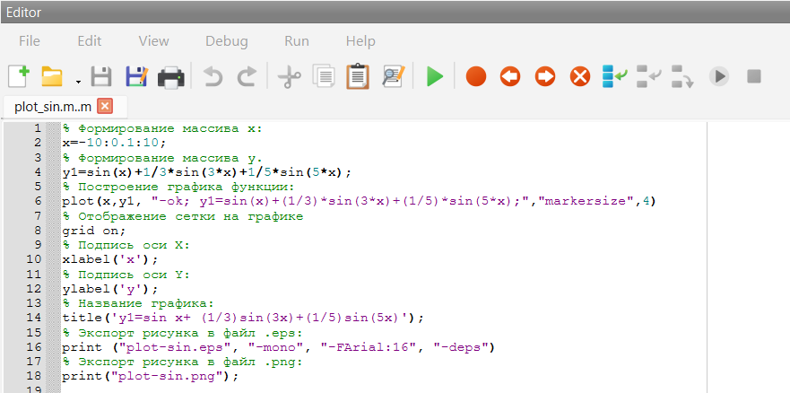

Программа plot_sin.m

## Программа plot_sin.m

Запустим сценарий. В качестве результата выполнения кода открылось окно с построенным графиком (рис. 2) и в рабочем каталоге появились файлы с графиками в форматах .eps, .png.

## Построенный график

[figure not shown]

Построенный график

## График с cos

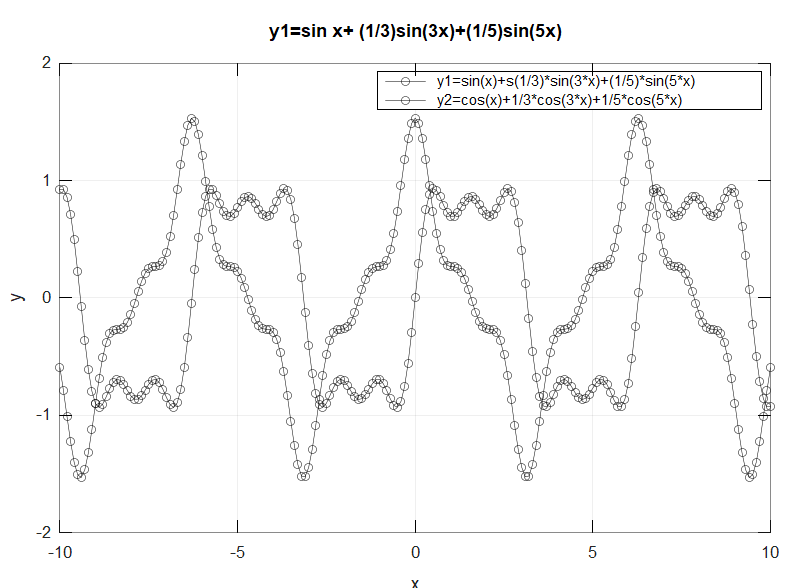

График с cos

## Разложение импульсного сигнала в частичный ряд Фурье

Создадим новый сценарий и сохраним его в рабочий каталог с именем meandr.m. В коде повторим листинг по построению графиков меандра. (рис. 5)

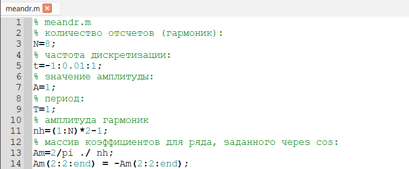

Код meandr.m

## Файл png

Экспортируем полученный график в файл в формате .png. (рис. 6)

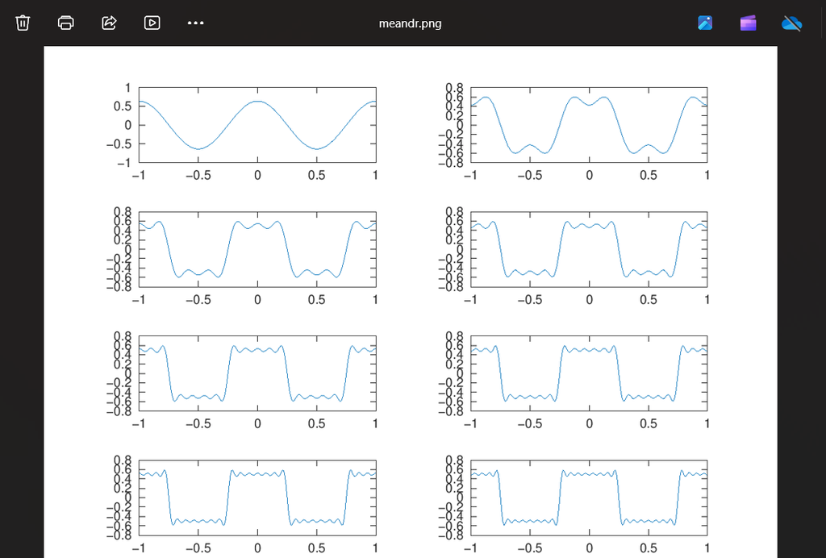

Файл png

## Меандр через синусы

Скорректируем код для реализации меандра через синусы. Получим графики. (рис. 7)

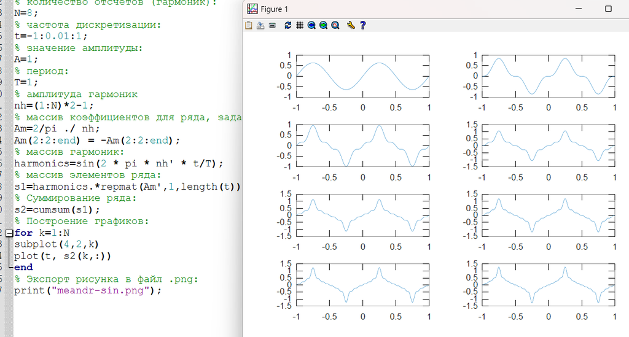

Меандр через синусы

## График сигналов разной частоты

Создадим каталог spectre1 и в нём новый сценарий с именем, spectre.m. В коде повторим листинг по построению сигналов разной частоты. (рис. 8)

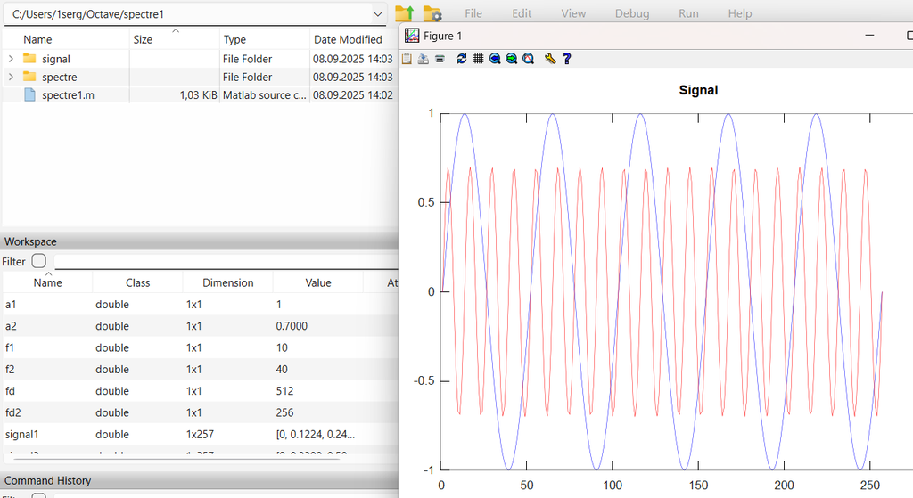

График сигналов разной частоты

## График спектра сигнала

Добавим код для нахождения спектров сигналов с помощью быстрого преобразования Фурье и получим график. (рис. 9)

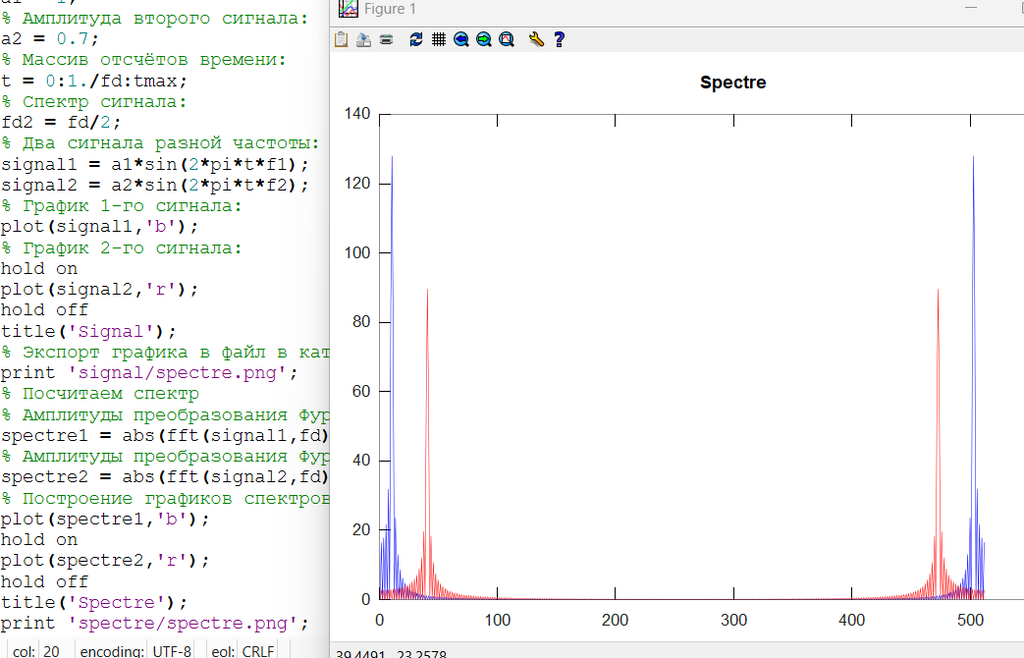

График спектра сигнала

## Скорректированный график спектра

Скорректируем график спектра: отбросим дублирующие отрицательные частоты, а также примем в расчёт то, что на каждом шаге вычисления быстрого преобразования Фурье происходит суммирование амплитуд сигналов. (рис. 10)

## Скорректированный график спектра

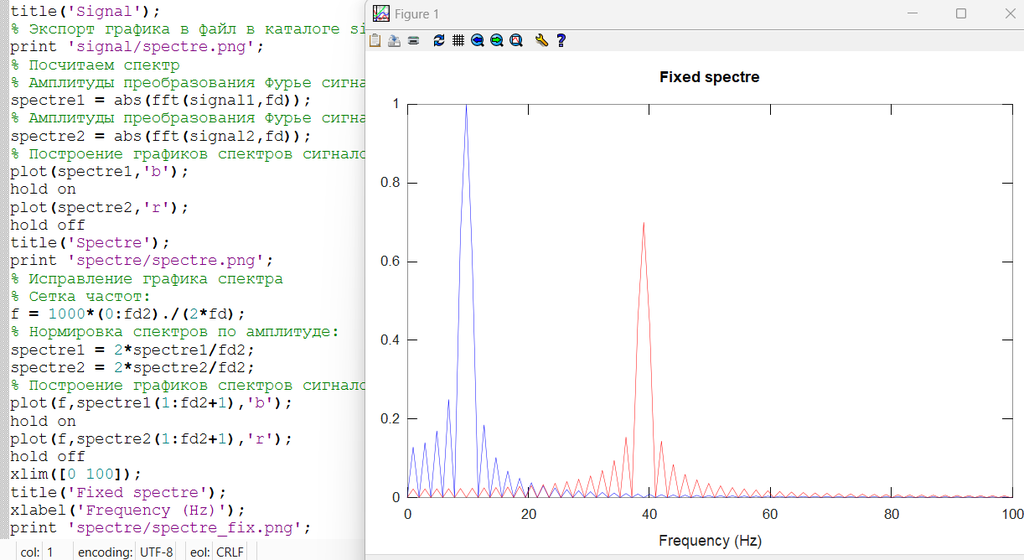

Скорректированный график спектра

## Графики суммарного сигнала

Найдем спектр суммы рассмотренных сигналов, создав каталог spectr_sum и файл в нём spectre_sum.m. В результате получился аналогичный предыдущему результат, т.е. спектр суммы сигналов равен сумме спектров сигналов, что вытекает из свойств преобразования Фурье. (рис. 11)

## Графики суммарного сигнала

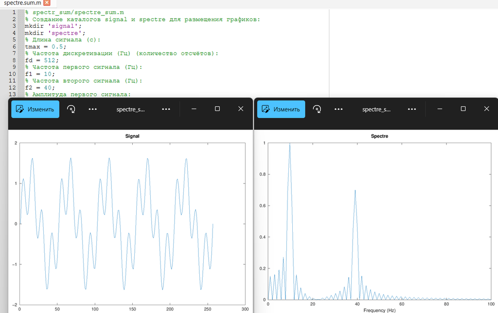

Графики суммарного сигнала

## Амплитудная модуляция

Создадим каталог modulation и в нём новый сценарий с именем am.m. Добавим в файле am.m код из листинга. (рис. 12)

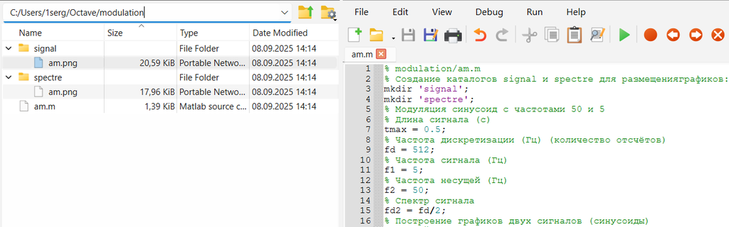

Каталог modulation

## Графики амплитудной модуляции

В результате получаем, что спектр произведения представляет собой свёртку спектров (рис. 13)

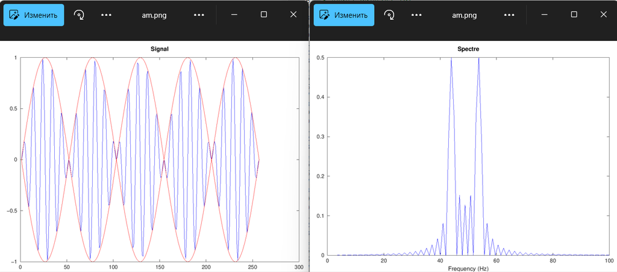

Графики амплитудной модуляции

## Кодирование сигнала. Исследование свойства самосинхронизации сигнала

Создадим каталог coding и в нём файлы main.m, maptowave.m,unipolar.m,ami.m,bipolarnrz.m,bipolarrz.m,manchester.m, diffmanc.m, calcspectre.m (рис. 14)

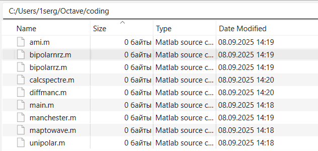

Создание файлов

## Проверка пакета

В окне интерпретатора команд проверим, установлен ли пакет расширений signal. Видим, что он установлен. (рис. 15)

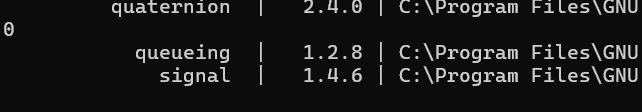

Проверка пакета

## Код main.m

В файле main.m подключим пакет signal и скопируем программу из листинга. (рис. 16)

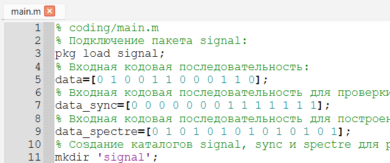

Код main.m

## Файл maptowave.m

В файле maptowave.m пропишем функцию, которая по входному битовому потоку строит график сигнала. (рис. 17)

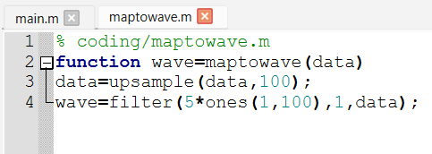

Файл maptowave.m

## Прописывание функций

В файлах unipolar.m, ami.m, bipolarnrz.m, bipolarrz.m, manchester.m, diffmanc.m пропишем соответствующие коды листингов. (рис. 18)

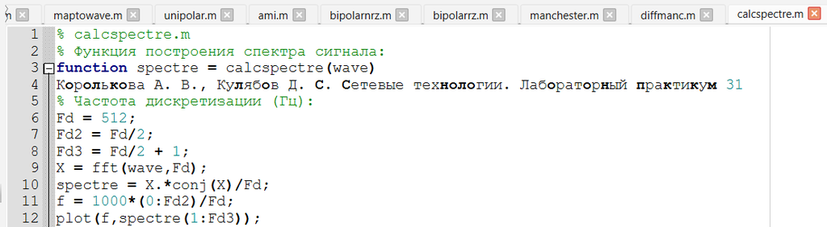

Прописывание функций

## Полученные графики

Запустим главный скрипт main.m. В каталоге signal получены файлы с графиками кодированного сигнала, в каталоге sync — файлы с графиками, иллюстрирующими свойства самосинхронизации, в каталоге spectre — файлы с графиками спектров сигналов. (рис. 19)

## Полученные графики

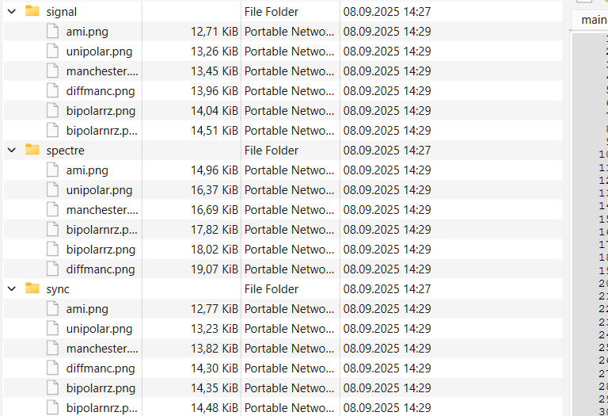

Полученные графики

## Задание с другой частотой дискретизации.

**1) Что будет, если взять частоту дискретизации меньше 80 Гц?**

При снижении частоты дискретизации ниже 80 Гц высокочастотные составляющие сигнала могут быть утеряны, что приведёт к искажению результатов спектрального анализа.

## Задание с другой частотой дискретизации

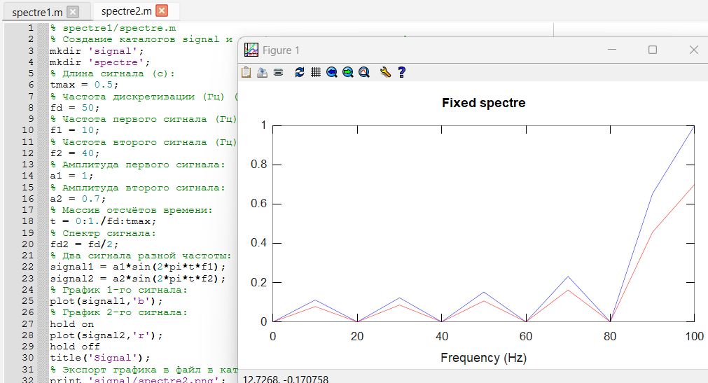

Задание с другой частотой дискретизации

# Вывод

## Вывод

В рамках лабораторной работы мы изучили методов кодирования и модуляции сигналов с помощью высокоуровнего языка программирования Octave. Определили спектра и параметров сигнала. Продемонстрировали принципы модуляции сигнала на примере аналоговой амплитудной модуляции. Исследовали свойства самосинхронизации сигнала.